# Cleaning WVS Data

# Analyzing the Characteristics of the Dummy Variables

## Analyzing the Characteristics of the Dummy Variables:Variance of Variables

Since the WVS has a variety of different question types, we wanted to look at the variance to determine if a specific type of question would mathematically appear in the components due to the structure of the question. Primarily we were concerned about questions which asked a yes or no question and those that asked a respondant to list 5 attributes they consider important and the variables were coded as mentioned or not mentioned. We first looked at the variance of all the variables, then the two category responses (yes or no), then the lists (mention or not mentioned).

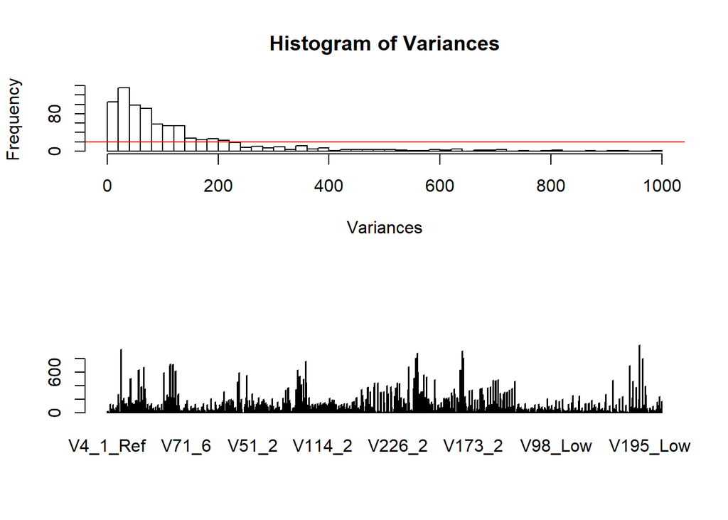

```r
Variances <- c()
for(i in 1:829){
  Question_Variance <- var(WVS_Data_Precentages4[,i])
  Variances <- cbind(Variances, Question_Variance)
}
colnames(Variances)<-colnames(WVS_Data_Precentages4)
Variance_Sorted <- t(Variances)

#pdf("Variance distribution.pdf", paper = "USr")
par(mfrow=c(2, 1))
hist(Variances, 50)
abline(h=20, col = "red")
barplot(Variances)
```

```r
#dev.off()
```

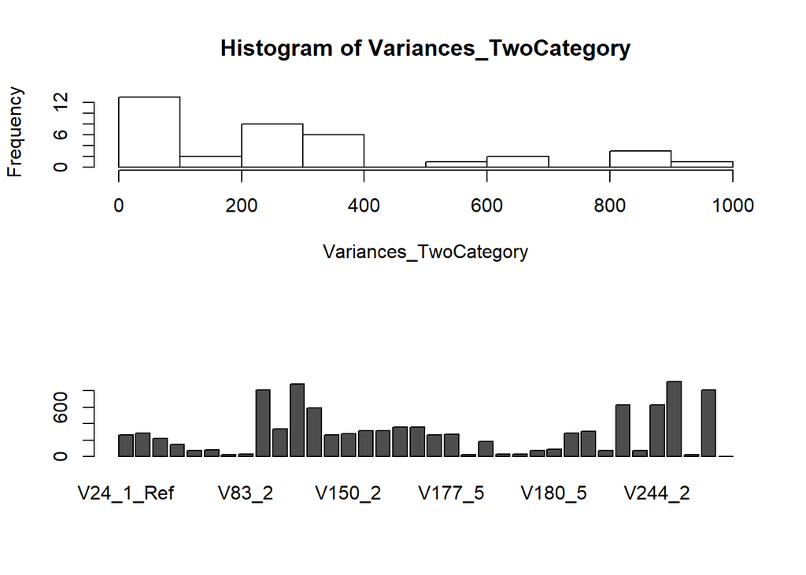

```r
#Break into two groups - Questions with 2 answers and those with more than 2 answers.
#Two answer questions: 12-22, 24, 36-44, 66, 82, 83, 148, 149, 150, 151, 176, 177, 178, 179, 180, 234, 235, 236, 240, 243, 244, 245,246, 250, 252

TwoCategoryQuestions<- WVS_Data_Precentages4[,c("V24_1_Ref","V24_2",
                                                "V66_1_Ref","V66_2",
                                                "V82_1_Ref","V82_2",
                                                "V83_1_Ref","V83_2" ,
                                                "V148_1_Ref","V148_2",
                                                "V149_1_Ref","V149_2",
                                                "V150_1_Ref","V150_2",
                                                "V151_1_Ref","V151_2",
                                                "V176_1_Ref","V176_5",
                                                "V177_1_Ref","V177_5",
                                                "V178_1_Ref","V178_5",
                                                "V179_1_Ref","V179_5",
                                                "V180_1_Ref","V180_5",
                                                "V187_1_Ref", "V187_2",
                                                "V243_1_Ref","V243_2",
                                                "V244_1_Ref","V244_2",
                                                "V245_1_Ref","V245_2",
                                                "V246_1_Ref","V246_2")]
Variances_TwoCategory<- c()
for(i in 1:36){
  Question_Variance_TwoCategory <- var(TwoCategoryQuestions[,i])
  Variances_TwoCategory <- cbind(Variances_TwoCategory, Question_Variance_TwoCategory)
}
colnames(Variances_TwoCategory)<-colnames(TwoCategoryQuestions)
Variance_Sorted_TwoCategory <- t(Variances_TwoCategory)
#pdf("Variance_TwoCategory distribution.pdf", paper = "USr")
par(mfrow=c(2, 1))
hist(Variances_TwoCategory)
barplot(Variances_TwoCategory)
```

```r
#dev.off()
```

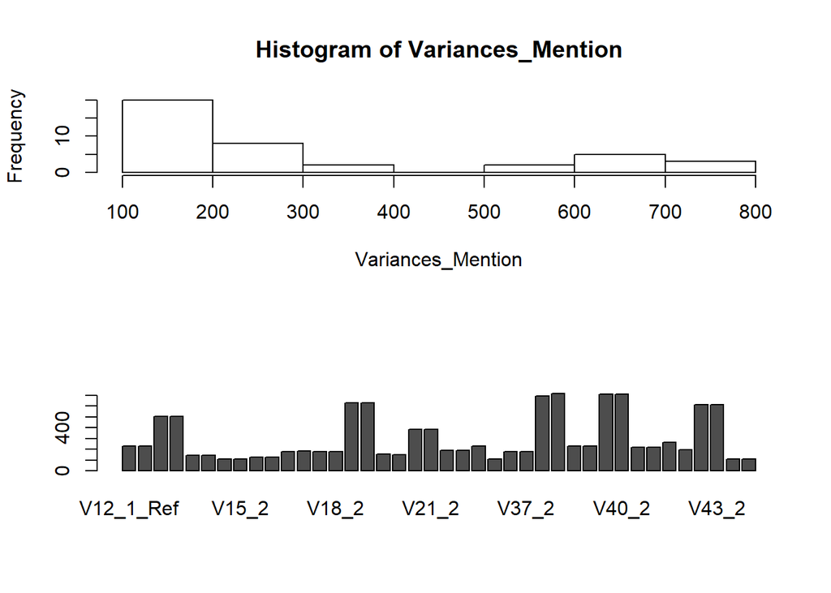

```r
MentionQuestions<- WVS_Data_Precentages4[,c("V12_1_Ref", "V12_2",
                                                       "V13_1_Ref", "V13_2",
                                                       "V14_1_Ref", "V14_2",
                                                       "V15_1_Ref", "V15_2",
                                                       "V16_1_Ref", "V16_2",
                                                       "V17_1_Ref", "V17_2",
                                                       "V18_1_Ref", "V18_2",
                                                       "V19_1_Ref", "V19_2",
                                                       "V20_1_Ref", "V20_2",
                                                       "V21_1_Ref", "V21_2",
                                                       "V22_1_Ref", "V22_2",
                                                       "V36_1_Ref", "V36_2",
                                                       "V37_1_Ref", "V37_2",
                                                       "V38_1_Ref", "V38_2",
                                                       "V39_1_Ref", "V39_2",
                                                       "V40_1_Ref", "V40_2",
                                                       "V41_1_Ref", "V41_2",
                                                       "V42_1_Ref", "V42_2",
                                                       "V43_1_Ref", "V43_2",
                                                       "V44_1_Ref", "V44_2")]
Variances_Mention<- c()
for(i in 1:40){
  Question_Variance_Mention <- var(MentionQuestions[,i])
  Variances_Mention <- cbind(Variances_Mention, Question_Variance_Mention)
}
colnames(Variances_Mention)<-colnames(MentionQuestions)
Variance_Sorted_Mention<- t(Variances_Mention)
#pdf("Variance_Mention distribution.pdf", paper = "USr")
par(mfrow=c(2, 1))
hist(Variances_Mention)
barplot(Variances_Mention)
```

```r
#dev.off()
```

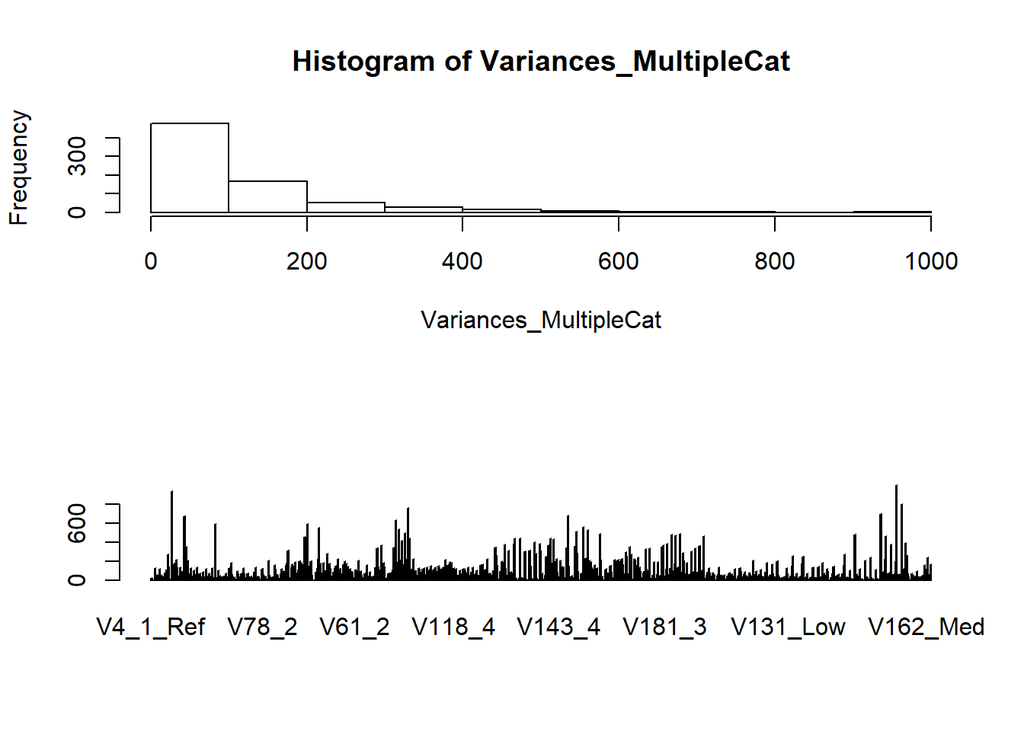

```r
remove <- c(colnames(TwoCategoryQuestions), colnames(MentionQuestions))
MultipleCat_Questions<- WVS_Data_Precentages4[,!colnames(WVS_Data_Precentages4) %in% remove]

Variances_MultipleCat<- c()
for(i in 1:753){
  Question_Variance_MultipleCat <- var(MultipleCat_Questions[,i])
  Variances_MultipleCat <- cbind(Variances_MultipleCat, Question_Variance_MultipleCat)
}
colnames(Variances_MultipleCat)<-colnames(MultipleCat_Questions)
Variance_Sorted_MultipleCat<- t(Variances_MultipleCat)

#pdf("Variance_MultipleCat distribution.pdf", paper = "USr")
par(mfrow=c(2, 1))
hist(Variances_MultipleCat)
barplot(Variances_MultipleCat)
```

```r
#dev.off()
```

For these plots, we decided to remove the “no” and “not_mention” variables from the principle component analysis because the variance will load in equal but opposite directions and could mask other relationships. Since we are removing the first category of each questions we don’t need to change the binary questions

```r
BinaryQuestions_RemoveVarible <- colnames(WVS_Data_Precentages4[,c("V12_2","V13_2", "V14_2", "V15_2",
                                                       "V16_2", "V17_2", "V18_2",
                                                       "V19_2",  "V20_2", "V21_2",
                                                       "V22_2", "V36_2", "V37_2",
                                                       "V38_2",  "V39_2", "V40_2",
                                                       "V41_2",  "V42_2", "V43_2",
                                                       "V44_2", "V24_2", "V66_2",
                                                       "V82_2","V83_2","V148_2","V149_2",
                                                       "V150_2", "V151_2","V176_5", "V177_5",
                                                       "V178_5","V179_5","V180_5","V187_2","V243_2",
                                                       "V244_2","V245_2", "V246_2")])


WVS_Data_Precentages5 <- WVS_Data_Precentages4[,!colnames(WVS_Data_Precentages4) %in% BinaryQuestions_RemoveVarible]
```

## Analyzing the Characteristics of the Dummy Variables: Normality Test

Multivariate Normality - requires variables to be independent https://cran.r-project.org/web/packages/MVN/vignettes/MVN.pdf

```r
#install.packages("nortest")
library("nortest")

normality_test <- apply(WVS_Data_Precentages5, 2, ad.test)

#Need to determine which variables have significant p-values
normality_p.values <- c()
variable_names <- colnames(WVS_Data_Precentages5)

for(col in c(1:791)){
  variable_normality <- normality_test[[col]]
  p.value <- variable_normality$p.value
  normality_p.values <- cbind(normality_p.values, p.value)
}

colnames(normality_p.values) <-variable_names

#p-values less than 0.05 mean the variables are non-normal
nonnormal_variables <- t(normality_p.values)
nonnormal_variables[nonnormal_variables > 0.01] = NA
nonnormal_variables <- as.data.frame(t(na.omit(nonnormal_variables)))

normal_variables <- t(normality_p.values)
normal_variables[normal_variables < 0.01] = NA
normal_variables <- as.data.frame(t(na.omit(normal_variables)))
```

## Analyzing the Characteristics of the Dummy Variables: Intercorrelation between Variables

Let’s take a look into how the variables are related - these relationships are a combination of lantent varaiables and the fact that they are dummy variables.

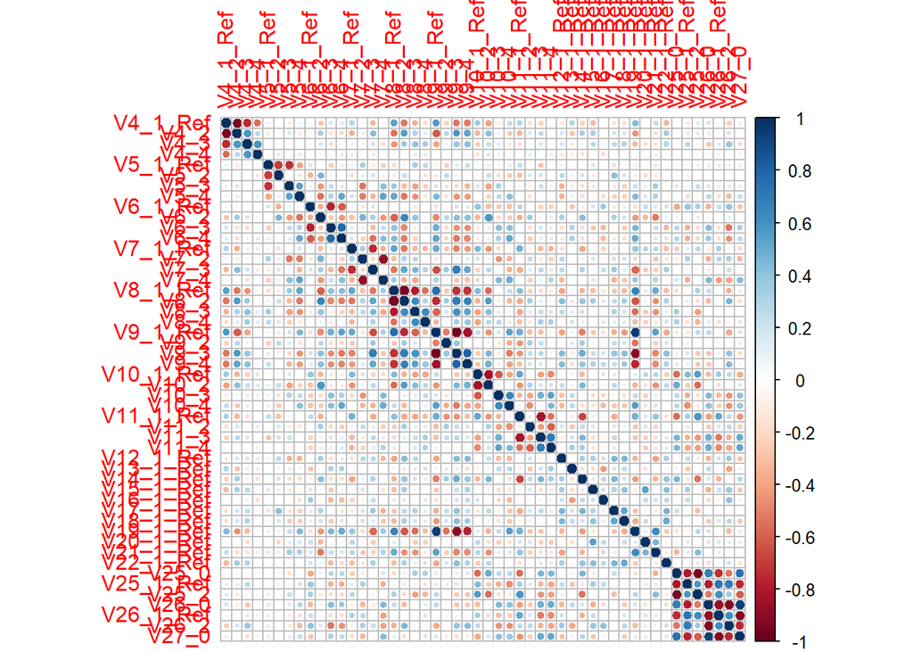

```r
library(corrplot)
corrplot(cor(as.matrix(WVS_Data_Precentages5[,1:50])))
```

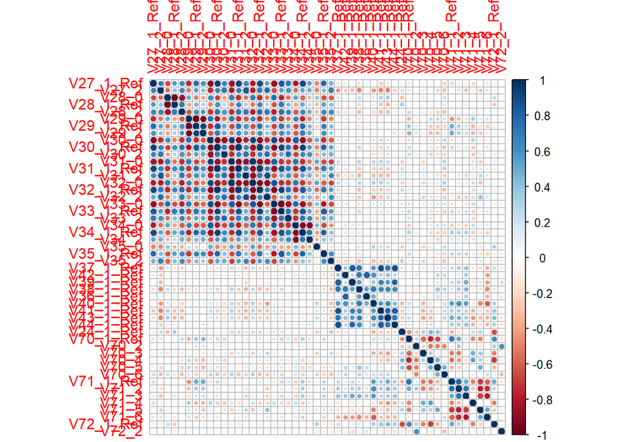

```r
corrplot(cor(as.matrix(WVS_Data_Precentages5[,51:100])))
```

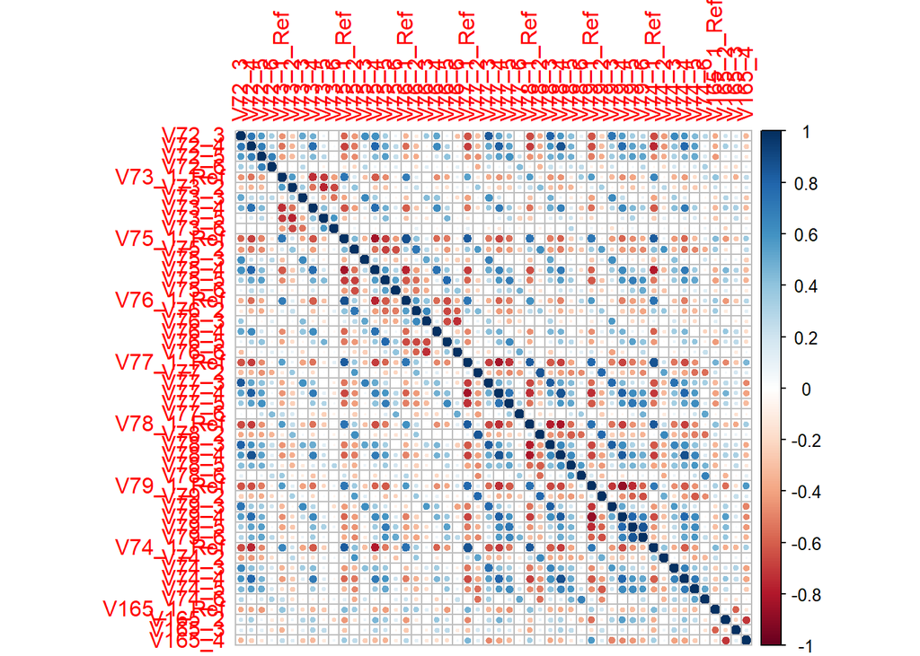

```r
corrplot(cor(as.matrix(WVS_Data_Precentages5[,101:150])))
```

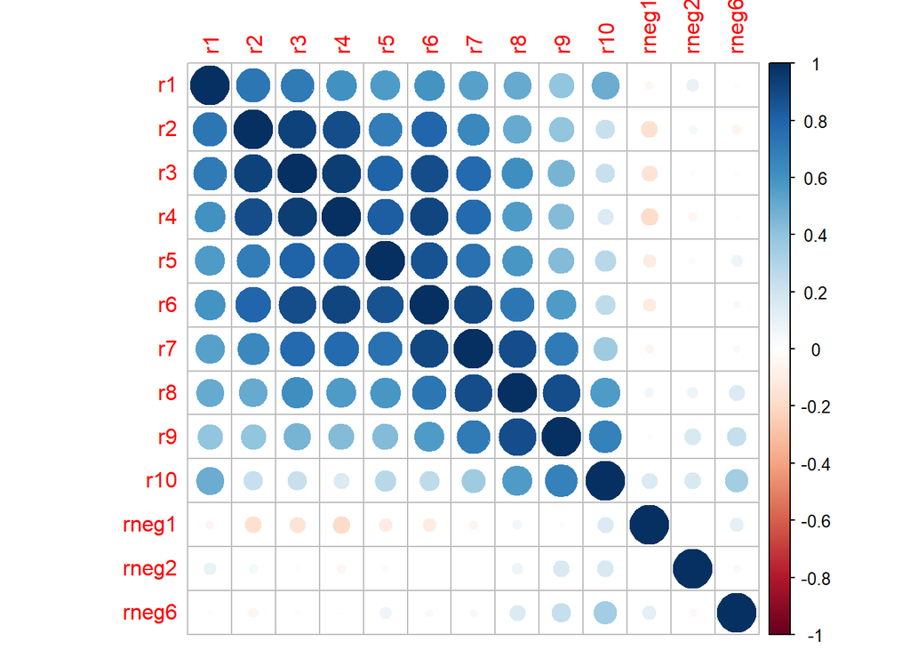

```r
corrplot(cor(V136_Count))
```

From this plot we can tell that the dummy variables are strongly correlated with other dummy variables from the same questions. This makes logical sense due to the way the dummy variables were created (i.e. porportion of the people from each country that answered that category). All the dummy variables for a single questions will sum to 100.

# Cluster Analysis

A simple way to see if variables are able to be dimensionally reduced is to perform a cluster analysis which analyses the points in space to determine which ones are “close” to each other.

```r
d <- dist(t(WVS_Data_Precentages5), method = "euclidean") # distance matrix
fit <- hclust(d, method="ward")
```

```
## The "ward" method has been renamed to "ward.D"; note new "ward.D2"
```

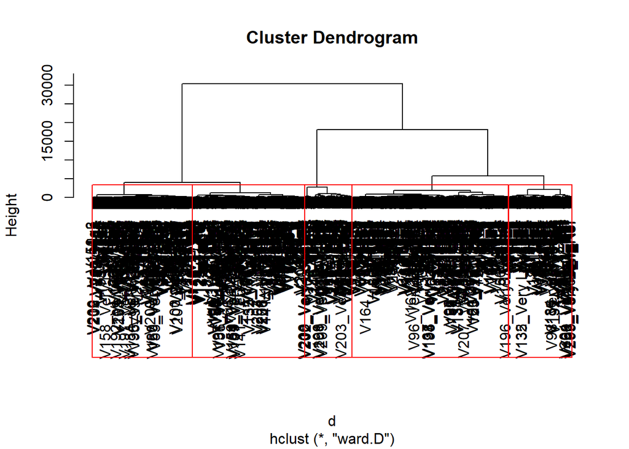

```r
plot(fit) # display dendogram
groups <- cutree(fit, k=5) # cut tree into 5 clusters
# draw dendogram with red borders around the 5 clusters
rect.hclust(fit, k=5, border="red")
```

From this cluster analysis we should expect the varaibles to group into approximately 5 dimensions.

# Data for PCA

Using WVS 4 instead of five because we don’t want to remove the binary questions completely.

```r
#Now that we have to remove our reference category before running the PCA.
WVS_Data_Precentages6<- WVS_Data_Precentages4[, -grep("Ref", colnames(WVS_Data_Precentages4))]
```

# Prinicple Component Analysis

The goal of principle component analysis is to reduce a set of correlated variables to a smaller number of uncorrelated varaibles.The goal is create a new set of varaibles that accounts for as much variability as possible. These principle components are linear combinations of the previous variables.Therefore, each component has a loading from the variables it is made up of.

When running a principle component analysis, either the correlation or covariance matrix can be used. the correlation matrix is primarily used when the data is on different scales. Since all the data is on a 0 to 100 scale, either correlation or covariance can be used. However, there must be more observations than variables to use the princomp function of R. Since our dataframe has more variables than observations, we sue the prcomp function which uses singular value decomposition to determine the components.

More details: http://www.sthda.com/english/wiki/principal-component-analysis-in-r-prcomp-vs-princomp-r-software-and-data-mining

```r
#Based on observation of the varianances, we decided to remove half of the binary variables - since they are essentially equal and opposite. We kept on the positive responses.

PCA_Analysis_Data <- WVS_Data_Precentages6
PCA_Analysis <-prcomp(PCA_Analysis_Data)
summary(PCA_Analysis)
```

```
## Importance of components:
##                            PC1      PC2      PC3      PC4      PC5
## Standard deviation     119.637 78.77644 69.72366 61.15222 53.35512
## Proportion of Variance   0.226  0.09799  0.07676  0.05905  0.04495
## Cumulative Proportion    0.226  0.32399  0.40075  0.45980  0.50475
##                             PC6      PC7      PC8      PC9     PC10
## Standard deviation     48.45841 46.95913 42.97912 42.82891 40.38600
## Proportion of Variance  0.03708  0.03482  0.02917  0.02896  0.02575
## Cumulative Proportion   0.54183  0.57665  0.60582  0.63478  0.66054
##                            PC11     PC12     PC13     PC14     PC15
## Standard deviation     38.52731 37.53715 34.62053 33.70991 31.73942
## Proportion of Variance  0.02344  0.02225  0.01893  0.01794  0.01591
## Cumulative Proportion   0.68398  0.70622  0.72515  0.74309  0.75900
##                            PC16     PC17     PC18     PC19    PC20
## Standard deviation     30.87691 29.46656 28.43737 28.05233 27.1090
## Proportion of Variance  0.01505  0.01371  0.01277  0.01243  0.0116
## Cumulative Proportion   0.77405  0.78776  0.80053  0.81296  0.8246
##                            PC21     PC22     PC23     PC24     PC25
## Standard deviation     25.98298 25.20256 24.16472 23.73377 23.13759
## Proportion of Variance  0.01066  0.01003  0.00922  0.00889  0.00845
## Cumulative Proportion   0.83522  0.84525  0.85447  0.86337  0.87182
##                            PC26     PC27     PC28     PC29     PC30
## Standard deviation     22.57545 22.28079 21.61185 21.30403 20.79741
## Proportion of Variance  0.00805  0.00784  0.00738  0.00717  0.00683
## Cumulative Proportion   0.87987  0.88771  0.89508  0.90225  0.90908
##                            PC31     PC32     PC33     PC34     PC35
## Standard deviation     20.24887 19.93859 18.58848 18.23402 18.01079
## Proportion of Variance  0.00647  0.00628  0.00546  0.00525  0.00512
## Cumulative Proportion   0.91555  0.92183  0.92729  0.93254  0.93766
##                            PC36    PC37     PC38     PC39     PC40
## Standard deviation     17.78301 17.4430 17.01012 16.67077 16.36326
## Proportion of Variance  0.00499  0.0048  0.00457  0.00439  0.00423
## Cumulative Proportion   0.94265  0.9475  0.95203  0.95641  0.96064
##                            PC41     PC42     PC43     PC44     PC45
## Standard deviation     15.64691 14.96442 14.64699 14.34437 14.05774
## Proportion of Variance  0.00387  0.00354  0.00339  0.00325  0.00312
## Cumulative Proportion   0.96451  0.96804  0.97143  0.97468  0.97780
##                            PC46     PC47    PC48     PC49     PC50
## Standard deviation     13.68610 13.39791 12.8257 12.45994 12.23190
## Proportion of Variance  0.00296  0.00283  0.0026  0.00245  0.00236
## Cumulative Proportion   0.98076  0.98359  0.9862  0.98864  0.99100
##                            PC51     PC52     PC53     PC54    PC55
## Standard deviation     11.64174 11.14071 10.87773 10.00460 9.57586
## Proportion of Variance  0.00214  0.00196  0.00187  0.00158 0.00145
## Cumulative Proportion   0.99314  0.99510  0.99697  0.99855 1.00000
##                             PC56
## Standard deviation     5.313e-14
## Proportion of Variance 0.000e+00
## Cumulative Proportion  1.000e+00
```

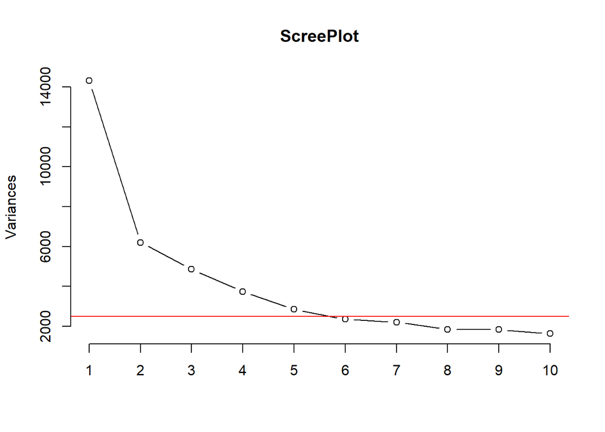

```r
plot(PCA_Analysis, main = "ScreePlot", type = "l")
abline(h=2500, col="red")
```